# PHD Batch 69 ID 3186

# Basic operations to understand the data:

```python
# Shape of CSV file
print(traindata.shape)
print(testdata.shape)
```

```
(27006, 11)
(11575, 10)
```

```python
# Shape of the json file
print(traindatajs.shape)
print(testdatajs.shape)
```

```
(1039131, 4)
(265022, 3)
```

```python
# Displays top 5 rows of csv file
traindata.head()
```

|  | Id | date | ticker | SF1 | SF2 | SF3 | SF4 | SF5 | SF6 | SF7 | alpha |
| --- | --- | --- | --- | --- | --- | --- | --- | --- | --- | --- | --- |
| 0 | 1 | 21/08/18 | $NTAP | -0.628652 | 0.988891 | -0.055714 | 0.774379 | 0.551089 | -1.329229 | -0.995539 | 2 |
| 1 | 2 | 11/10/18 | $WYNN | 1.315786 | 1.438754 | 0.187327 | 0.608933 | -1.153030 | 1.859441 | 0.730995 | 3 |
| 2 | 3 | 21/08/18 | $DRI | -1.141388 | -1.455016 | 0.332755 | 0.674502 | 0.111326 | -0.478597 | -1.488157 | 1 |
| 3 | 4 | 10/07/18 | $ge | -0.054839 | -1.454149 | -0.162267 | -0.681870 | 0.307869 | -0.529987 | 0.404172 | 2 |
| 4 | 5 | 12/09/18 | $FE | -0.686366 | 0.838865 | 0.073830 | 0.679024 | 0.329463 | 1.262782 | -1.024042 | 2 |

```python
testdata.head()
```

|  | Id | date | ticker | SF1 | SF2 | SF3 | SF4 | SF5 | SF6 | SF7 |
| --- | --- | --- | --- | --- | --- | --- | --- | --- | --- | --- |
| 0 | 270007 | 21/07/18 | $INTC | -3.062194 | 1.223466 | 1.741714 | 2.279266 | -1.323573 | -0.274912 | -4.504449 |
| 1 | 270008 | 05/10/18 | $CTSH | 0.816263 | -2.184408 | 0.157975 | -0.264743 | -0.836282 | 0.046276 | 0.826353 |
| 2 | 270009 | 01/10/18 | $CB | 0.401281 | 0.091604 | 0.083411 | -1.147041 | -0.485223 | -0.601060 | 1.012811 |
| 3 | 270010 | 24/10/18 | $CTAS | -0.783521 | 1.192929 | 0.813831 | -0.368166 | -1.113656 | -0.553581 | -0.683803 |
| 4 | 270011 | 27/07/18 | $intc | 0.796507 | 0.455341 | 0.679032 | 0.354336 | -1.799055 | 0.126153 | 0.297111 |

```python
# Displaying top 5 rows of json file
traindatajs.head()
```

|  | sentiment_score | stocktwit_tweet | ticker | timestamp |
| --- | --- | --- | --- | --- |
| 0 | 3 | $AMD going up but hesitating however chart is very stable and going upward | $AMD | 2018-09-19 18:38:28+00:00 |
| 1 | 3 | @inforlong @MariaGascon Despite\nChina trade war $CAT held very well 👍 | $CAT | 2018-10-09 03:51:06+00:00 |
| 10 | 2 | $NFLX called it Friday hahahaha suckers sold Friday | $NFLX | 2018-08-27 12:51:21+00:00 |
| 100 | 4 | $LMT Chug chug!!! No effect whatsoever on all the noise going on! $345 soon! | $LMT | 2018-09-17 19:15:14+00:00 |
| 1000 | 0 | @Jaedjohnson ... are you a Registered $AAPL Financial Advisor, or is anyone asking for your &quot;bearish&quot; advice? Get Out ?!? | $AAPL | 2018-08-03 15:54:30+00:00 |

```python
testdatajs.head()
```

|  | stocktwit_tweet | ticker | timestamp |
| --- | --- | --- | --- |
| 0 | $CELG nothing to be exited about | $CELG | 2018-10-25 14:26:16+00:00 |
| 1 | $AMD yall exhaust your buyer on first green candle,,,, byeeeeee | $AMD | 2018-07-13 13:50:39+00:00 |
| 10 | $AMD FINALLY AMD GOT ITS ANTI-GRAVITY TECHNOLOGY,,,AND 7 NM | $AMD | 2018-08-24 14:31:18+00:00 |
| 100 | @AMSI Buy $MU ;) | $MU | 2018-08-31 01:05:29+00:00 |
| 1000 | $NFLX guess it’s time to shake off some Bears. Overcrowded trade there. MMs are dirty like that lol. | $NFLX | 2018-10-29 14:23:40+00:00 |

```python
# List out features
print(list(traindata.columns))
```

```
['Id', 'date', 'ticker', 'SF1', 'SF2', 'SF3', 'SF4', 'SF5', 'SF6', 'SF7', 'alpha']
```

```python
# Data types of train and test data
print(traindata.dtypes)
print(testdata.dtypes)
print(traindatajs.dtypes)
print(testdatajs.dtypes)
```

```
Id          int64
date       object
ticker     object
SF1       float64
SF2       float64
SF3       float64
SF4       float64
SF5       float64
SF6       float64
SF7       float64
alpha       int64
dtype: object
Id          int64
date       object
ticker     object
SF1       float64
SF2       float64
SF3       float64
SF4       float64
SF5       float64
SF6       float64
SF7       float64
dtype: object
sentiment_score                  int64
stocktwit_tweet                 object
ticker                          object
timestamp          datetime64[ns, UTC]
dtype: object
stocktwit_tweet                 object
ticker                          object
timestamp          datetime64[ns, UTC]
dtype: object
```

```python
#Convert features to the data type as required
for col in ['ticker','stocktwit_tweet']:
    traindatajs[col] = traindatajs[col].astype('category')
```

```python
for col in ['ticker', 'stocktwit_tweet']:
    testdatajs[col] = testdatajs[col].astype('category')
```

```python
print(traindatajs.dtypes)
print(testdatajs.dtypes)
```

```
sentiment_score                  int64
stocktwit_tweet               category
ticker                        category
timestamp          datetime64[ns, UTC]
dtype: object
stocktwit_tweet               category
ticker                        category
timestamp          datetime64[ns, UTC]
dtype: object
```

```python
# Summary statistics of data
traindata.describe(include='all')
```

|  | Id | date | ticker | SF1 | SF2 | SF3 | SF4 | SF5 | SF6 | SF7 | alpha |
| --- | --- | --- | --- | --- | --- | --- | --- | --- | --- | --- | --- |
| count | 27006.000000 | 27006 | 27006 | 27006.000000 | 27006.000000 | 27006.000000 | 27006.000000 | 27006.000000 | 27006.000000 | 27006.000000 | 27006.000000 |
| unique | NaN | 123 | 1304 | NaN | NaN | NaN | NaN | NaN | NaN | NaN | NaN |
| top | NaN | 26/07/18 | $BAC | NaN | NaN | NaN | NaN | NaN | NaN | NaN | NaN |
| freq | NaN | 344 | 90 | NaN | NaN | NaN | NaN | NaN | NaN | NaN | NaN |
| mean | 13503.500000 | NaN | NaN | 0.005429 | -0.001005 | -0.024421 | -0.042420 | 0.041465 | 0.002597 | 0.036744 | 2.379582 |
| std | 7796.105021 | NaN | NaN | 0.941853 | 0.996130 | 0.539555 | 1.111309 | 0.976028 | 0.998839 | 1.204473 | 1.008681 |
| min | 1.000000 | NaN | NaN | -4.114670 | -4.578587 | -2.609150 | -6.329798 | -5.480268 | -4.338751 | -5.347869 | 1.000000 |
| 25% | 6752.250000 | NaN | NaN | -0.596792 | -0.666310 | -0.300187 | -0.767247 | -0.518641 | -0.668027 | -0.688198 | 2.000000 |
| 50% | 13503.500000 | NaN | NaN | 0.012104 | -0.013257 | -0.040786 | -0.058629 | 0.072127 | 0.007417 | 0.081374 | 2.000000 |
| 75% | 20254.750000 | NaN | NaN | 0.611574 | 0.669094 | 0.241424 | 0.677433 | 0.616538 | 0.674592 | 0.807556 | 3.000000 |
| max | 27006.000000 | NaN | NaN | 4.415048 | 3.822270 | 3.452486 | 4.907407 | 4.779911 | 4.075428 | 5.182912 | 4.000000 |

```python
testdata.describe(include='all')
```

|  | Id | date | ticker | SF1 | SF2 | SF3 | SF4 | SF5 | SF6 | SF7 |
| --- | --- | --- | --- | --- | --- | --- | --- | --- | --- | --- |
| count | 11575.000000 | 11575 | 11575 | 11575.000000 | 11575.000000 | 11575.000000 | 11575.000000 | 11575.000000 | 11575.000000 | 11575.000000 |
| unique | NaN | 123 | 1012 | NaN | NaN | NaN | NaN | NaN | NaN | NaN |
| top | NaN | 25/07/18 | $AMZN | NaN | NaN | NaN | NaN | NaN | NaN | NaN |
| freq | NaN | 152 | 46 | NaN | NaN | NaN | NaN | NaN | NaN | NaN |
| mean | 275794.000000 | NaN | NaN | 0.001546 | 0.003995 | -0.029754 | -0.047606 | 0.053956 | -0.000428 | 0.037914 |
| std | 3341.559017 | NaN | NaN | 0.924519 | 0.997903 | 0.537651 | 1.097842 | 0.965109 | 1.003503 | 1.192223 |
| min | 270007.000000 | NaN | NaN | -4.130410 | -4.034445 | -4.259227 | -4.704038 | -4.545787 | -4.317883 | -5.031257 |
| 25% | 272900.500000 | NaN | NaN | -0.580470 | -0.673206 | -0.308838 | -0.754051 | -0.502280 | -0.682896 | -0.684029 |
| 50% | 275794.000000 | NaN | NaN | 0.011865 | -0.001464 | -0.044590 | -0.055108 | 0.084598 | 0.008303 | 0.081955 |
| 75% | 278687.500000 | NaN | NaN | 0.600965 | 0.685805 | 0.228484 | 0.649046 | 0.620426 | 0.680800 | 0.807105 |
| max | 281581.000000 | NaN | NaN | 4.519223 | 4.108285 | 2.763214 | 4.794511 | 5.646556 | 3.900014 | 6.005315 |

```python
# Function to get month in Word format
def num_to_word(x):
    return dt.datetime.strftime(x, format = '%b')
```

```python
# Creating new column Month
traindatajs['Month'] = traindatajs.loc[:,'timestamp'].apply(num_to_word)
```

```python
testdatajs['Month'] = testdatajs.loc[:,'timestamp'].apply(num_to_word)
```

```python
# Displaying top 5 rows to check the new month column
traindatajs.head()
```

|  | sentiment_score | stocktwit_tweet | ticker | timestamp | Month |
| --- | --- | --- | --- | --- | --- |
| 0 | 3 | $AMD going up but hesitating however chart is very stable and going upward | $AMD | 2018-09-19 18:38:28+00:00 | Sep |
| 1 | 3 | @inforlong @MariaGascon Despite\nChina trade war $CAT held very well 👍 | $CAT | 2018-10-09 03:51:06+00:00 | Oct |
| 10 | 2 | $NFLX called it Friday hahahaha suckers sold Friday | $NFLX | 2018-08-27 12:51:21+00:00 | Aug |
| 100 | 4 | $LMT Chug chug!!! No effect whatsoever on all the noise going on! $345 soon! | $LMT | 2018-09-17 19:15:14+00:00 | Sep |
| 1000 | 0 | @Jaedjohnson ... are you a Registered $AAPL Financial Advisor, or is anyone asking for your &quot;bearish&quot; advice? Get Out ?!? | $AAPL | 2018-08-03 15:54:30+00:00 | Aug |

```python
testdatajs.head()
```

|  | stocktwit_tweet | ticker | timestamp | Month |
| --- | --- | --- | --- | --- |
| 0 | $CELG nothing to be exited about | $CELG | 2018-10-25 14:26:16+00:00 | Oct |
| 1 | $AMD yall exhaust your buyer on first green candle,,,, byeeeeee | $AMD | 2018-07-13 13:50:39+00:00 | Jul |
| 10 | $AMD FINALLY AMD GOT ITS ANTI-GRAVITY TECHNOLOGY,,,AND 7 NM | $AMD | 2018-08-24 14:31:18+00:00 | Aug |
| 100 | @AMSI Buy $MU ;) | $MU | 2018-08-31 01:05:29+00:00 | Aug |
| 1000 | $NFLX guess it’s time to shake off some Bears. Overcrowded trade there. MMs are dirty like that lol. | $NFLX | 2018-10-29 14:23:40+00:00 | Oct |

```python
# Sorting the data with respect to time stamp
traindatajs = traindatajs.sort_values(by=['timestamp'])
```

```python
# Sorting the data with respect to time stamp
testdatajs = testdatajs.sort_values(by=['timestamp'])
```

```python
# Creating new feature Day and checking timestamp sorting and day
traindatajs['Day'] = traindatajs['timestamp'].dt.weekday_name
traindatajs.head()
```

|  | sentiment_score | stocktwit_tweet | ticker | timestamp | Month | Day |
| --- | --- | --- | --- | --- | --- | --- |
| 928506 | 4 | $FITB great buy at 26.00...ill wait | $FITB | 2018-07-01 00:00:09+00:00 | Jul | Sunday |
| 618057 | 3 | @StockTwits $MSFT | $MSFT | 2018-07-01 00:00:42+00:00 | Jul | Sunday |
| 101989 | 3 | $AMD I heard there’s a guy who knows someone who thinks somebody knows something - on StockTwits. | $AMD | 2018-07-01 00:01:47+00:00 | Jul | Sunday |
| 582604 | 2 | $AMD reveal yourself! | $AMD | 2018-07-01 00:02:13+00:00 | Jul | Sunday |
| 262836 | 3 | $AAPL Why the drop? I warren Buffet taking out his position? | $AAPL | 2018-07-01 00:03:10+00:00 | Jul | Sunday |

```python
# Creating new feature Day and checking timestamp sorting and day
testdatajs['Day'] = testdatajs['timestamp'].dt.weekday_name
testdatajs.head()
```

|  | stocktwit_tweet | ticker | timestamp | Month | Day |
| --- | --- | --- | --- | --- | --- |
| 242499 | #STAAnalystAlert for $TDG : Jefferies Maintains with a rating of Hold setting target price at USD 350.00. Our own verdict is Buy http://www.stocktargetadvisor.com/toprating | $TDG | 2018-07-01 00:01:24+00:00 | Jul | Sunday |
| 86410 | $SNPS short ratio is 2.17 at 2018-06-15 and short % to float is 1.42% http://sunshineavenue.com/stock/SNPS/ via @sunshineave | $SNPS | 2018-07-01 00:09:36+00:00 | Jul | Sunday |
| 15537 | $NFLX price squeezing,perfect place for an option straddle near the supporting trend | $NFLX | 2018-07-01 00:12:58+00:00 | Jul | Sunday |
| 206362 | Short volume percent for $URI was 35.42% on 06-28-18 and 20 day rank was ~20th percentile https://volumebot.com/?s=URI | $URI | 2018-07-01 00:30:01+00:00 | Jul | Sunday |
| 263423 | $K has a better Return On Equity than the industry average of 40.97%. https://www.chartmill.com/analyze.php?utm_source=stocktwits&amp;utm_medium=FA&amp;utm_content=PROFITABILITY&amp;utm_campaign=socia… | $K | 2018-07-01 00:32:03+00:00 | Jul | Sunday |

```python
# Unique values in Day column
traindatajs.Day.unique()
```

```
array(['Sunday', 'Monday', 'Tuesday', 'Wednesday', 'Thursday', 'Friday',
       'Saturday'], dtype=object)
```

```python
# Creating new dataframe for storing value counts with respect to day
Week_data = pd.DataFrame(pd.Series(traindatajs.Day.value_counts()))
Week_data
```

|  | Day |
| --- | --- |
| Thursday | 220231 |
| Wednesday | 218214 |
| Tuesday | 208086 |
| Friday | 170646 |
| Monday | 166159 |
| Saturday | 30381 |
| Sunday | 25414 |

```python
Week_data = Week_data.reset_index()
Week_data = Week_data.rename(columns  = {"index": "Weekday", "Day":"ReviewCount"})
Week_data.head()
```

|  | Weekday | ReviewCount |
| --- | --- | --- |
| 0 | Thursday | 220231 |
| 1 | Wednesday | 218214 |
| 2 | Tuesday | 208086 |
| 3 | Friday | 170646 |
| 4 | Monday | 166159 |

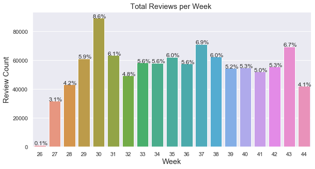

```python
# Total reviews per week in percentile
total = 262064 + 253905 + 274333 + 248829
sns.set(rc={'figure.figsize':(10,5)})
plot = sns.countplot(x=traindatajs['timestamp'].dt.week ,data=traindatajs)
plt.title("Total Reviews per Week ",fontsize=15)
plt.xlabel("Week",fontsize=15)
plt.ylabel("Review Count",fontsize=15)
for p in plot.patches:
    plot.annotate('{:.1f}%'.format(100*p.get_height()/total), (p.get_x(), p.get_height()+10))
```

30th week has highest reviews done by buyers(i.e July last week). Similarly, week 33-36 and 39-42 are approximately in the similar range, which means that there might be less variation in the stocks.

```python
# Obtaining count of sentiment scores with respect to day
day_sc = traindatajs[['Day','sentiment_score']]
day_sc = pd.DataFrame(day_sc.groupby('Day')['sentiment_score'].value_counts())
day_sc.reset_index(level=0, inplace=True)
day_sc = day_sc.rename(columns  = {"Day": "Day", "sentiment_score":"sentiment_count"})
day_sc = day_sc.reset_index()
day_sc.head()
```

|  | sentiment_score | Day | sentiment_count |
| --- | --- | --- | --- |
| 0 | 2 | Friday | 73213 |
| 1 | 3 | Friday | 34969 |
| 2 | 4 | Friday | 26934 |
| 3 | 1 | Friday | 19628 |
| 4 | 0 | Friday | 15902 |

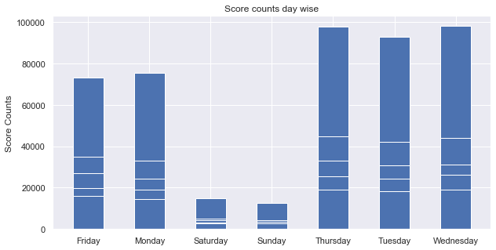

```python
# Bar plot for score counts with respect to days.
width = 0.5
p = plt.bar(day_sc.Day, day_sc.sentiment_count,width)
plt.ylabel('Score Counts')
plt.title('Score counts day wise')
plt.show()
```

Wednesday and Thursday people tend to tweet more than on other days. No share market takes place during weekends, hence there is huge drop.

```python
# Creating a copy of traindata
traindata1 = traindata
traindata1.head()
```

|  | Id | date | ticker | SF1 | SF2 | SF3 | SF4 | SF5 | SF6 | SF7 | alpha |
| --- | --- | --- | --- | --- | --- | --- | --- | --- | --- | --- | --- |
| 0 | 1 | 21/08/18 | $NTAP | -0.628652 | 0.988891 | -0.055714 | 0.774379 | 0.551089 | -1.329229 | -0.995539 | 2 |
| 1 | 2 | 11/10/18 | $WYNN | 1.315786 | 1.438754 | 0.187327 | 0.608933 | -1.153030 | 1.859441 | 0.730995 | 3 |
| 2 | 3 | 21/08/18 | $DRI | -1.141388 | -1.455016 | 0.332755 | 0.674502 | 0.111326 | -0.478597 | -1.488157 | 1 |
| 3 | 4 | 10/07/18 | $ge | -0.054839 | -1.454149 | -0.162267 | -0.681870 | 0.307869 | -0.529987 | 0.404172 | 2 |
| 4 | 5 | 12/09/18 | $FE | -0.686366 | 0.838865 | 0.073830 | 0.679024 | 0.329463 | 1.262782 | -1.024042 | 2 |

```python
# Creating a copy of testdata
testdata1 = testdata
testdata1.head()
```

|  | Id | date | ticker | SF1 | SF2 | SF3 | SF4 | SF5 | SF6 | SF7 |
| --- | --- | --- | --- | --- | --- | --- | --- | --- | --- | --- |
| 0 | 270007 | 21/07/18 | $INTC | -3.062194 | 1.223466 | 1.741714 | 2.279266 | -1.323573 | -0.274912 | -4.504449 |
| 1 | 270008 | 05/10/18 | $CTSH | 0.816263 | -2.184408 | 0.157975 | -0.264743 | -0.836282 | 0.046276 | 0.826353 |
| 2 | 270009 | 01/10/18 | $CB | 0.401281 | 0.091604 | 0.083411 | -1.147041 | -0.485223 | -0.601060 | 1.012811 |
| 3 | 270010 | 24/10/18 | $CTAS | -0.783521 | 1.192929 | 0.813831 | -0.368166 | -1.113656 | -0.553581 | -0.683803 |
| 4 | 270011 | 27/07/18 | $intc | 0.796507 | 0.455341 | 0.679032 | 0.354336 | -1.799055 | 0.126153 | 0.297111 |

```python
# Type conversion of ticker and data in train and test data.
traindata1['ticker'] = traindata1['ticker'].astype('category')
traindata1['date'] = traindata1['date'].astype('datetime64[ns]')
traindata1.dtypes
```

```
Id                 int64
date      datetime64[ns]
ticker          category
SF1              float64
SF2              float64
SF3              float64
SF4              float64
SF5              float64
SF6              float64
SF7              float64
alpha              int64
dtype: object
```

```python
# The date and ticker has to be converted to it respective data types.
testdata1['ticker'] = testdata1['ticker'].astype('category')
testdata1['date'] = testdata1['date'].astype('datetime64[ns]')
testdata1.dtypes
```

```
Id                 int64
date      datetime64[ns]
ticker          category
SF1              float64
SF2              float64
SF3              float64
SF4              float64
SF5              float64
SF6              float64
SF7              float64
dtype: object
```